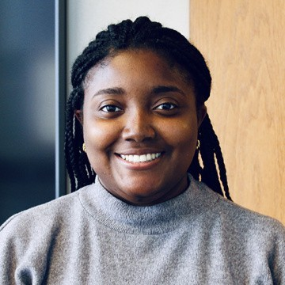

# Helen Webley-Brown

## Hello!

I am a second-year Ph.D. student in Political Science at MIT with specializations in American Politics and Quantitative Methods.

My current research agenda fits into two broad buckets:

1. Socio-political effects of interacting with the criminal legal system.
2. How emerging technologies change the way people experience and perceive the state.

At the intersection of this, I am interested in pre-trial electronic monitoring, and the role of tools like ShotSpotter and Flock in policing.

I also have a nascent interest in how political violence targeted at elected officials impacts the representation of gender and racial minorities.

Although my research focuses on the US, I grew up in London, England. I moved across the pond via the US-UK Fulbright Commission’s wonderful [*Sutton Trust US Programme*](https://us.suttontrust.com/).

## Education

**Massachusetts Institute of Technology** | Cambridge, MA

Ph.D. in Political Science | 2022 - Present

**Washington University** | St. Louis, MO

A.B. in Political Science | 2018 - 2022

## Research

King, J., Ho, D., Gupta, A., Wu, V., **Webley-Brown, H**. (2023). [*The Privacy-Bias Tradeoff: Data Minimization and Racial Disparity Assessments in U.S. Government*](https://dl.acm.org/doi/10.1145/3593013.3594015). ACM Conference on Fairness, Accountability, and Transparency (FAccT).

- **Best Paper Award** at FAccT 2023.